# Comandos básicos no R voltados ao curso

06 e 07 de Dezembro de 2014

## Preliminares

## O que é R?

R é uma linguagem de programação e um ambiente de desenvolvimento integrado, para cálculos estatísticos e gráficos.

## Interfaces para o R

Para trabalhar mais eficientemente com o R você vai precisar de uma interface, ou de um ambiente de desenvolvimento (IDE - Integrated Development Environment).

São ambientes de programação que combinam ferramentas para escrever e executar seu código de maneira mais fácil e eficiente.

## Interface sugerida: R Studio

Primeiro IDE criado especificamente para R. Seu ponto forte é a organização das janelas em um arranjo fixo e de fácil acesso.

Simples e intuitivo, é uma das melhores opções para começar: http://www.rstudio.org

## O ambiente de trabalho

**Script, Console, Global Environment, Files/Plots/Help/Viewer**

[figure not shown]

## Use o # para comentar códigos no seu script!!

## Use # e comente seus códigos no script

data (plethodon) # carrega os dados

plethodon # olhe o conteudo do objeto plethodon

names (plethodon) # olhe os nomes dentro do objeto plethodon

class (plethodon) # mostra a classe a que pertence o objeto plethodon

## Como trabalhar com o R no Curso de Morfometria Geométrica?

- Vamos criar uma pasta para o Curso e armazená-la no diretório que você preferir (Desktop, Meus Documentos…);
- Sempre que iniciar o R você precisa checar em qual diretório de tabalho está;
- Para isso vamos usar: getwd() e setwd().

## getwd() e setwd()

**Qual o diretório de trabalho atual?**

getwd()

[1] "/Users/dani/Copy/MGeo"

**Muda o diretório de trabalho**

setwd("/Users/dani/Copy/MGeo/Introducao R")

**Verificando…**

getwd()

[1] "/Users/dani/Copy/MGeo/Introducao R"

## Ou, vá na janela no canto inferior direito do RStudio…

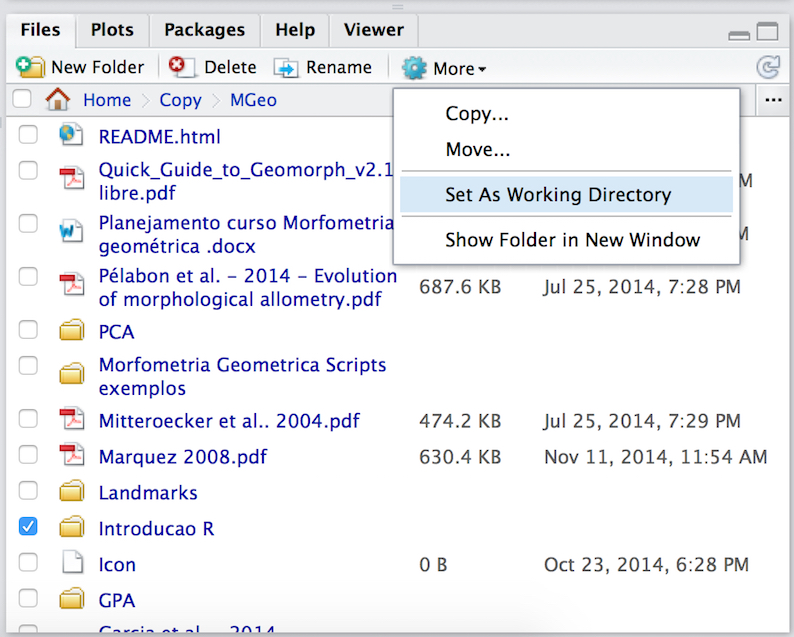

## Qual os arquivos presentes no meu diretório ou pasta de trabalho?

getwd() # onde estou?

[1] "/Users/dani/Copy/MGeo/Introducao R"

dir() # o que há dentro de Introducao R?

[1] "Ambiente de trabalho small.jpg" "Ambiente de trabalho.jpg"  
[3] "Ambiente de trabalho.png" "Set as working directory.jpg"  
[5] "presintroR.Rmd" "presintroR.html"

## Instalando e carregando pacotes no R

## install.packages()

Instala pacotes

## install.packages()

install.packages ("geomorph")

Installing package into '/Users/dani/Library/R/3.0/library' (as 'lib' is unspecified) trying URL 'http://cran.rstudio.com/bin/macosx/contrib/3.0/geomorph_2.1.1.tgz' Content type 'application/x-gzip' length 414710 bytes (404 Kb) opened URL ================================================== downloaded 404 Kb

## install.packages()

install.packages ("ggplot2")

Installing package into '/Users/dani/Library/R/3.0/library' (as 'lib' is unspecified) trying URL 'http://cran.rstudio.com/bin/macosx/contrib/3.0/ggplot2_1.0.0.tgz' Content type 'application/x-gzip' length 2660507 bytes (2.5 Mb) opened URL ================================================== downloaded 2.5 Mb

## require()

Carrega pacotes

## require()

require (geomorph)

Loading required package: geomorph

Loading required package: rgl

require (ggplot2)

Loading required package: ggplot2

## Operadores <- , =

## Operadores e objetos

**objeto <- expressão**

aves.area <- c(50, 67, 26, 22, 47, 16, 21)

**objeto = expressão**

aves.area = c(50, 67, 26, 22, 47, 16, 21)

**objeto <- expressão**

aves.riqueza <- c(10, 15, 6, 18, 5, 11, 20)

**objeto = expressão**

aves.riqueza = c(10, 15, 6, 18, 5, 11, 20)

## Digite o nome do objeto para exibí-lo

aves.area

[1] 50 67 26 22 47 16 21

aves.riqueza

[1] 10 15 6 18 5 11 20

Você acabou de criar dois objetos (veja no Global Environment)

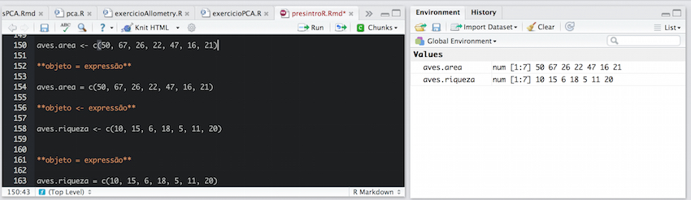

## Linguagem orientada a objetos

## Linguagem orientada a objetos

aves.area <- c(50, 67, 26, 22, 47, 16, 21)

aves.area

[1] 50 67 26 22 47 16 21

summary (aves.area) # mostra resultados resumidos

Min. 1st Qu. Median Mean 3rd Qu. Max.

16.00 21.50 26.00 35.57 48.50 67.00

## ls()

**Lista os objetos**

ls()

## Sintaxe básica das funções

função (argumento1 = valor, argumento2=valor)

?plotTangentSpace # essa função do geomorph faz uma PCA

args(plotTangentSpace) # vamos olhar os argumentos da função

function (A, axis1 = 1, axis2 = 2, warpgrids = TRUE, mesh = NULL, label = NULL, groups = NULL, verbose = FALSE)

## USE O HELP

## 3 maneiras de chamar o help:

help(summary)

?summary

Ou na janela inferior direita do RStudio digitando no help o que procura

## O help fornece

- Descrição da função
- Como usar a função
- Os argumentos da função
- Detalhes
- Referências
- Exemplos

## Tipos de dados no R ("Atomic data types")

## Tipos de dados

**1 - Numeric:**

value <- 605

value

[1] 605

## Tipos de dados

**2 - Character:**

string <- "Hello World"

string

[1] "Hello World"

## Tipos de dados

**3 - Logical:**

2 < 4

[1] TRUE

## Tipos de dados

**4 - Complex number:**

cn <- 2+3i

cn

[1] 2+3i

## Tipos de Objetos no R

## Tipos de Objetos

**1 - Vetor:** contém várias cópias de um mesmo tipo de objeto. Um vetor pode conter somente objetos de mesma classe.

atenção para a função c() (catenate)

meu.vetor <- c(10.5,11.3,12.4,5.7)

meu.vetor

[1] 10.5 11.3 12.4 5.7

## Tipos de Objetos

**2 - Matriz:** um array de duas dimensões com número arbitrário de linhas e colunas

minha.matriz <- matrix(data=1:12,nrow=3,ncol=4)

minha.matriz

```
     [,1] [,2] [,3] [,4]
[1,]    1    4    7   10
[2,]    2    5    8   11
[3,]    3    6    9   12
```

## Tipos de Objetos

**3 - Array:** como uma matriz, mas com dimensões arbitrárias (isto é, mais do que duas dimensões)

my.array <- array(1:24, dim=c(3,4,2))

my.array <- array(1:24, dim=c(3,4,2))

my.array

```
, , 1

     [,1] [,2] [,3] [,4]
[1,]    1    4    7   10
[2,]    2    5    8   11
[3,]    3    6    9   12

, , 2

     [,1] [,2] [,3] [,4]
[1,]   13   16   19   22
[2,]   14   17   20   23
[3,]   15   18   21   24
```

## Tipos de Objetos

**4 - Data frame:** conjunto de dados organizados, similar a uma matriz. Entretanto, cada coluna do data frame deverá conter um tipo de dado.

Com a função data.frame reunimos vetores de mesmo comprimento em um só objeto.

nome <- c("Didi","Dede","Mussum","Zacarias")

ano.nasc <- c(1936,1936,1941,1934)

vive <- c("V","V","F","F")

trapalhoes <- data.frame(nome,ano.nasc,vive)

trapalhoes

```
      nome ano.nasc vive
1     Didi     1936    V
2     Dede     1936    V
3   Mussum     1941    F
4 Zacarias     1934    F
```

O mesmo, em um só comando:

trapalhoes <- data.frame(nomes=c("Didi","Dedé","Mussum","Zacarias"), ano.nasc=c(1936,1936,1941,1934), vive=c("V","V","F","F"))

[output not shown]

## Tipos de Objetos

**5 - Function:** conjunto de comandos com entrada (input) e saída (output) definidos.

## Tipos de Objetos

**6 - Lista:** coleção arbitrária de outros objetos de R (os quais podem incluir outras listas). Pode conter objetos de diferentes classes.

data(plethodon) # carrega os dados

plethodon

São dados do pacote *geomorph* referentes à salamandra do gênero *Plethodon*.

```
$land
, , 1
[,1] [,2]
[1,] 8.89372 53.77644
[2,] 9.26840 52.77072
[3,] 5.56104 54.21028
[4,] 1.87340 52.75100
...
$links
[,1] [,2]
[1,] 4 5
[2,] 3 5
[3,] 2 4
[4,] 1 2
[5,] 1 3
[6,] 6 7
...
```

```
$species
[1] Jord Jord Jord Jord Jord Jord Jord Jord Jord Jord Teyah Teyah Teyah Teyah Teyah Teyah Teyah
[18] Teyah Teyah Teyah Jord Jord Jord Jord Jord Jord Jord Jord Jord Jord Teyah Teyah Teyah Teyah
[35] Teyah Teyah Teyah Teyah Teyah Teyah
Levels: Jord Teyah

$site
[1] Symp Symp Symp Symp Symp Symp Symp Symp Symp Symp Symp Symp Symp Symp Symp Symp Symp Symp Symp Symp
Allo Allo Allo Allo Allo Allo Allo Allo Allo Allo Allo Allo Allo Allo Allo Allo Allo Allo Allo Allo
Levels: Allo Symp
```

### A base de dados **plethodon é uma lista** que contém quatro componentes:

- as coordenadas dos dados - landmarks (plethodon$land);
- the wirelink addresses for plotting (plethodon$links);
- dois conjuntos de variáveis como fatores species e sites

### Classe a que pertencem os componentes da lista

class(plethodon$site)

[1] "factor"

class(plethodon$land)

[1] "array"

class(plethodon$links)

[1] "matrix"

**Investigue o conteúdo do objeto plethodon**

names(plethodon) # olhe os nomes dentro do objeto plethodon

[1] "land" "links" "species" "site"

class(plethodon) # mostra a classe a que pertence o objeto

[1] "list"

**Investigue a estrutura do objeto plethodon**

str(plethodon)

```
List of 4
 $ land   : num [1:12, 1:2, 1:40] 8.89 9.27 5.56 1.87 1.28 ...
  ..- attr(*, "dimnames")=List of 3
  .. ..$ : NULL
  .. ..$ : NULL
  .. ..$ : NULL
 $ links  : num [1:14, 1:2] 4 3 2 1 1 6 7 8 9 10 ...
 $ species: Factor w/ 2 levels "Jord","Teyah": 1 1 1 1 1 1 1 1 1 1 ...
 $ site   : Factor w/ 2 levels "Allo","Symp": 2 2 2 2 2 2 2 2 2 2 ..
```

## Funções básicas no R que ajudam a entender o formato dos dados

## Funções básicas no R

class() # a classe do objeto

attributes() # atributo do objeto (lista)

dim() # dimensões do objeto

nrow() ; ncol() # número de linhas/colunas de uma matriz

dimnames() # nome da dimensão do objeto

names() # o nome de um objeto

rownames() ; colnames() # nome de linhas e colunas

is.numeric() # é muito útil saber se os dados são numéricos ou não - dataframes geralmente não mantém os dados como numéricos, mesmo que sejam números.

## O que é mais importante sabermos para o Curso?

## *Geomorph*

- Armazena dados principalmente em 2D array ou 3D array (**matriz e array**, respectivamente);
- As variáveis agrupadoras são **vetores** e **fatores**;
- Os outputs das funções podem ser uma **lista**

## Landmarks no geomorph

### Dois tipos de objetos:

**Matriz** (figura A) e **Array** (figura B)

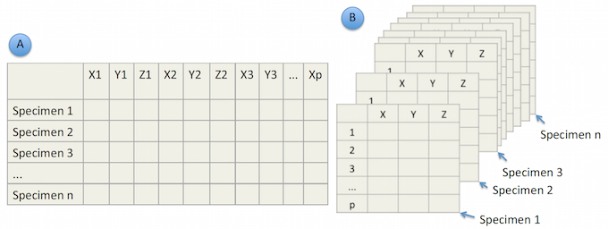

## Recordando matriz e array

## Array

```r
my.array <- array(1:24, dim=c(3,4,2))
my.array
```

```
## , , 1
##
##      [,1] [,2] [,3] [,4]
## [1,]    1    4    7   10
## [2,]    2    5    8   11
## [3,]    3    6    9   12
##
## , , 2
##
##      [,1] [,2] [,3] [,4]
## [1,]   13   16   19   22
## [2,]   14   17   20   23
## [3,]   15   18   21   24
```

## Matriz

```r
minha.matriz <- matrix(data=1:12,nrow=3,ncol=4)
minha.matriz
```

```
##      [,1] [,2] [,3] [,4]
## [1,]    1    4    7   10
## [2,]    2    5    8   11
## [3,]    3    6    9   12
```

## Recordando lista

## Lista

```r
pts <- list(x = cars[,1], y = cars[,2])
pts
```

```
## $x
##  [1]  4  4  7  7  8  9 10 10 10 11 11 12 12 12 12 13 13 13 13 14 14 14 14
## [24] 15 15 15 16 16 17 17 17 18 18 18 18 19 19 19 20 20 20 20 20 22 23 24
## [47] 24 24 24 25
##
## $y
##  [1]   2  10   4  22  16  10  18  26  34  17  28  14  20  24  28  26  34
## [18]  34  46  26  36  60  80  20  26  54  32  40  32  40  50  42  56  76
## [35]  84  36  46  68  32  48  52  56  64  66  54  70  92  93 120  85
```

## Processo de análise morfométrica no *geomorph*

**Azul:** passos realizados no R e *geomorph*.

**Alaranjado:** passos realizados fora do R e importados para o R.

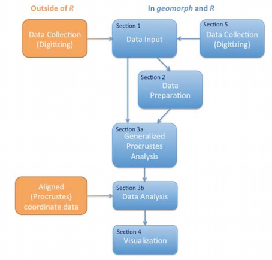

Algumas questões ou análises e funções no *geomorph*

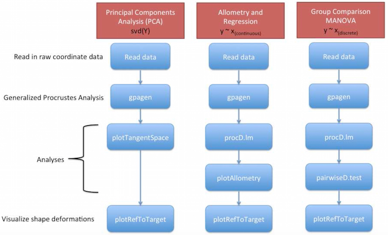